# **IEMS-490 : MIDTERM**

**STUDENT INFO**

- Name: Ayush Agarwal
- NetID : scg1143

# **Question 1**

Are the recurrent architecture (RNN with only one layer) and the attention architecture (transformer with only one layer) invariant/equivariant to permutations of inputs, i.e., giving the same set of outputs (reordered) upon reordering the input sequence

# **Answer 1**

### 1. **Recurrent Architecture (RNN with only one layer)**

For a single-layer RNN, the hidden state at each time step depends on both the current input and the hidden state from the previous time step. This means that RNNs inherently process sequences in an ordered fashion.

- **Invariance/Equivariance:** A single-layer RNN is **neither invariant nor equivariant** to input permutations. If you reorder the input sequence, the RNN's outputs will likely change completely because each element's position in the sequence influences how the hidden state is updated. Changing the order of inputs disrupts this dependency chain, so there’s no straightforward relationship between the original output and the output of the reordered sequence.

### 2. **Attention Architecture (Transformer with only one layer)**

Transformers, particularly self-attention layers, calculate pairwise dependencies between all elements in a sequence without explicit sequential processing, which suggests they may handle permutations differently from RNNs.

#### Case A: **Transformer Without Positional Encoding**

Without positional encoding, the self-attention mechanism has no information about the order of inputs; it treats all positions as indistinguishable.

- **Invariance/Equivariance:** A Transformer without positional encoding is **equivariant** to permutations of inputs. Since there is no positional information, reordering the input will reorder the output in the same way. For example, if the input tokens are shuffled, the output will reflect this shuffling without changing the content, essentially "following" the permutation applied to the input.

#### Case B: **Transformer With Positional Encoding**

With positional encoding, each input position has a unique embedding that represents its relative or absolute position in the sequence. This positional information is added to the input embeddings before they are fed to the attention layers, which allows the model to distinguish among different positions in the sequence.

- **Invariance/Equivariance:** A Transformer with positional encoding is **neither invariant nor equivariant** to input permutations. The positional encoding ties each input to its specific position, so reordering inputs leads to outputs that are not directly aligned with the permutation of the inputs. The change in input ordering disrupts the positional encoding and the resulting attention patterns, which in turn affects the output structure in a non-permutative manner.

# **Question2**

**Approach**

- Formulating problem statement as last time step prediction problem, where the model takes in input number of previous steps and predict the next step.
- The MSE Loss is applied at the last time step value to calculate and back propagate the errors.
- For mid-term scope, I am keeping hidden dimension fix at 64 due to low input dimension. I am going to experiment by varying different head size (2,4,8) and conclude the experiment with what works the best.

```python
import pandas as pd
import os
from pathlib import Path

import torch
import torch.nn as nn
import torch.optim as optim
from torch.utils.data import Dataset, DataLoader, random_split
import numpy as np
from scipy.stats import pearsonr
```

```python
# Read Data
data_dir = Path.cwd() / 'data'

checkpoint_dir = data_dir / 'checkpoints'
os.makedirs(checkpoint_dir, exist_ok=True)

feature_names = ['x1', 'x2', 'x3']

train_data = pd.read_csv(data_dir / 'training_data+.csv', names=feature_names)
test_data_init = pd.read_csv(data_dir / 'testing_data_initial+.csv', names=feature_names)
test_data_ref = pd.read_csv(data_dir / 'Reference/testing_data_rest+.csv', names=feature_names)

print(f"Train Data Len : {train_data.shape}")
print(f"Inital Test Data Len : {test_data_init.shape}")
print(f"Reference Test Data Len : {test_data_ref.shape}")
```

```
Train Data Len : (990000, 3)
Inital Test Data Len : (100, 3)
Reference Test Data Len : (9900, 3)
```

```python
print("Train Data")
for feature_name in feature_names:
    print("Feature Name",feature_name)
    print(f"Max:{train_data[feature_name].min():.3f} Min:{train_data[feature_name].max():.3f}")

print("\nInitial Test Data")
for feature_name in feature_names:
    print("Feature Name",feature_name)
    print(f"Max:{test_data_init[feature_name].min():.3f} Min:{test_data_init[feature_name].max():.3f}")

print("\nReference Test Data")
for feature_name in feature_names:
    print("Feature Name",feature_name)
    print(f"Max:{test_data_ref[feature_name].min():.3f} Min:{test_data_ref[feature_name].max():.3f}")
```

```
Train Data
Feature Name x1
Max:-4.149 Min:4.178
Feature Name x2
Max:-3.423 Min:4.107
Feature Name x3
Max:-2.585 Min:2.521

Initial Test Data
Feature Name x1
Max:-2.425 Min:3.613
Feature Name x2
Max:-2.316 Min:2.304
Feature Name x3
Max:-1.907 Min:2.294

Reference Test Data
Feature Name x1
Max:-4.149 Min:4.178
Feature Name x2
Max:-3.416 Min:4.101
Feature Name x3
Max:-2.584 Min:2.521
```

```python
class TimeSeriesDataset(Dataset):
    def __init__(self, data, seq_len):
        self.data = torch.tensor(data, dtype=torch.float32)
        self.seq_len = seq_len

    def __len__(self):
        return len(self.data) - self.seq_len

    def __getitem__(self, idx):
        x = self.data[idx:idx + self.seq_len]
        y = self.data[idx + self.seq_len]
        return x, y
```

```python
class MultiHeadAttention(nn.Module):
    def __init__(self, d_in, d_out, dropout, num_heads, qkv_bias=False):
        super().__init__()
        assert d_out % num_heads == 0, "d_out must be divisible by num_heads"

        self.d_out = d_out
        self.num_heads = num_heads
        self.head_dim = d_out // num_heads # Reduce the projection dim to match desired output dim

        self.W_query = nn.Linear(d_in, d_out, bias=qkv_bias)
        self.W_key = nn.Linear(d_in, d_out, bias=qkv_bias)
        self.W_value = nn.Linear(d_in, d_out, bias=qkv_bias)
        self.out_proj = nn.Linear(d_out, d_out)  # Linear layer to combine head outputs
        self.dropout = nn.Dropout(dropout)

    def forward(self, x):
        b, num_tokens, d_in = x.shape

        keys = self.W_key(x) # Shape: (b, num_tokens, d_out)
        queries = self.W_query(x)
        values = self.W_value(x)

        # We implicitly split the matrix by adding a `num_heads` dimension
        # Unroll last dim: (b, num_tokens, d_out) -> (b, num_tokens, num_heads, head_dim)
        keys = keys.view(b, num_tokens, self.num_heads, self.head_dim)
        values = values.view(b, num_tokens, self.num_heads, self.head_dim)
        queries = queries.view(b, num_tokens, self.num_heads, self.head_dim)

        # Transpose: (b, num_tokens, num_heads, head_dim) -> (b, num_heads, num_tokens, head_dim)
        keys = keys.transpose(1, 2)
        queries = queries.transpose(1, 2)
        values = values.transpose(1, 2)

        # Compute scaled dot-product attention (aka self-attention) with a causal mask
        attn_scores = queries @ keys.transpose(2, 3)  # Dot product for each head

        attn_weights = torch.softmax(attn_scores / keys.shape[-1]**0.5, dim=-1)
        attn_weights = self.dropout(attn_weights)

        # Shape: (b, num_tokens, num_heads, head_dim)
        context_vec = (attn_weights @ values).transpose(1, 2)

        # Combine heads, where self.d_out = self.num_heads * self.head_dim
        context_vec = context_vec.contiguous().view(b, num_tokens, self.d_out)
        context_vec = self.out_proj(context_vec) # optional projection
        return context_vec, attn_weights

# Transformer class
class Transformer(nn.Module):
    def __init__(self, num_heads, output_dim, d_in=3, d_model=64, dropout=0.1):
        super().__init__()
        self.multihead_attention = MultiHeadAttention(d_in, d_model, dropout, num_heads)
        self.regression_head = nn.Sequential(
            nn.Linear(d_model, d_model),
            nn.LayerNorm(d_model),
            nn.ReLU(),
            nn.Dropout(dropout),

            nn.Linear(d_model, d_model),
            nn.LayerNorm(d_model),
            nn.ReLU(),
            nn.Dropout(dropout),

            nn.Linear(d_model, output_dim)
        )

    def forward(self, x):
        x, attn_weights = self.multihead_attention(x)
        return self.regression_head(x[:, -1, :]),  attn_weights
```

```python
def evaluate_model(model, dataloader, device):
    model.eval()
    mse_loss = 0
    predictions, targets = [], []

    with torch.no_grad():
        for x_batch, y_batch in dataloader:
            x_batch, y_batch = x_batch.to(device), y_batch.to(device)
            pred, _ = model(x_batch)
            mse_loss += nn.functional.mse_loss(pred, y_batch).item()
            predictions.append(pred.cpu().numpy())
            targets.append(y_batch.cpu().numpy())

    predictions = np.concatenate(predictions)
    targets = np.concatenate(targets)
    mse = mse_loss / len(dataloader)
    corr = pearsonr(predictions.flatten(), targets.flatten())[0]  # Pearson correlation

    return mse, corr

def train_model(model,
                train_loader,
                val_loader,
                criterion,
                optimizer,
                device,
                save_dir,
                epochs=10
                ):
    model.to(device)
    best_val_mse = float("inf")
    best_model_path = save_dir / "best_model.pth"
    print(f"Best Model Path : {best_model_path} Num Epochs : {epochs}")

    train_loss_list = []
    val_loss_list = []

    for epoch in range(epochs):
        model.train()
        train_loss = 0
        for x_batch, y_batch in train_loader:
            x_batch, y_batch = x_batch.to(device), y_batch.to(device)
            optimizer.zero_grad()
            predictions, _ = model(x_batch)

            if torch.isnan(predictions).any():
                print("NaN detected in predictions, stopping training.")
                return

            loss = criterion(predictions, y_batch)
            loss.backward()
            optimizer.step()
            train_loss += loss.item()

        train_loss = train_loss / len(train_loader)
        # Validation
        val_mse, val_corr = evaluate_model(model, val_loader, device)
        print(f"Epoch {epoch + 1}/{epochs}, Train Loss: {train_loss:.3f}, Validation MSE: {val_mse:.3f}, Validation Correlation: {val_corr:.3f}")

        # Save the model if it has the best validation MSE
        if val_mse < best_val_mse:
            best_val_mse = val_mse
            torch.save(model.state_dict(), best_model_path)
            print(f"New best model saved with Validation MSE: {best_val_mse}")

        train_loss_list.append(train_loss)
        val_loss_list.append(val_mse)

    print(f"Training complete. Best model saved with Validation MSE: {best_val_mse}")
    return train_loss_list, val_loss_list
```

```python
SEQ_LEN=100
BATCH_SIZE=512
TRAIN_TEST_SPLIT=0.8
NUM_EPOCHS=10

LEARNING_RATE=0.001

criterion = nn.MSELoss()

if torch.backends.mps.is_available():
    print("Setting Device as MPS")
    device = torch.device("mps")
else:
    print("Setting Device as CPU")
    device = torch.device('cpu')
```

```
Setting Device as MPS
```

```python
raw_data = np.array(train_data)
seq_len = SEQ_LEN

dataset = TimeSeriesDataset(raw_data, seq_len)
train_size = int(TRAIN_TEST_SPLIT * len(dataset))
val_size = len(dataset) - train_size
train_dataset, val_dataset = random_split(dataset, [train_size, val_size])

train_loader = DataLoader(train_dataset, batch_size=BATCH_SIZE, shuffle=True)
val_loader = DataLoader(val_dataset, batch_size=BATCH_SIZE)
```

### Experiment 1

- d_in = 3
- d_model = 64
- num_heads = 2
- output_dim = 3

```python
model = Transformer(
    num_heads=2,
    output_dim=3,
    d_in=3,
    d_model=64)
optimizer = optim.Adam(model.parameters(), lr=LEARNING_RATE)
save_dir = checkpoint_dir / 'num_heads_2'
os.makedirs(save_dir, exist_ok=True)

train_loss_list, val_loss_list = train_model(model,
                train_loader,
                val_loader,
                criterion,
                optimizer,
                device,
                save_dir,
                epochs=NUM_EPOCHS)
```

```
Best Model Path : /Users/dare_devil/Documents/MLDS_2024/Quarter4/IEMS-490/Assignments/Midterm/data/checkpoints/num_heads_2/best_model.pth Num Epochs : 10
New best model saved with Validation MSE: 0.578034943388414
New best model saved with Validation MSE: 0.4629094740063029
New best model saved with Validation MSE: 0.3989234390338878
New best model saved with Validation MSE: 0.3518845589894041
New best model saved with Validation MSE: 0.32030149108371686
New best model saved with Validation MSE: 0.2955826935225987
New best model saved with Validation MSE: 0.2852156900004207
New best model saved with Validation MSE: 0.26427811711487537
New best model saved with Validation MSE: 0.2622213282018361
New best model saved with Validation MSE: 0.24194901769629437
Training complete. Best model saved with Validation MSE: 0.24194901769629437
```

### Experiment 2

- d_in = 3
- d_model = 64
- num_heads = 4
- output_dim = 3

```python
model = Transformer(
    num_heads=4,
    output_dim=3,
    d_in=3,
    d_model=64)
optimizer = optim.Adam(model.parameters(), lr=LEARNING_RATE)
save_dir = checkpoint_dir / 'num_heads_4'
os.makedirs(save_dir, exist_ok=True)

train_loss_list, val_loss_list = train_model(model,
                train_loader,
                val_loader,
                criterion,
                optimizer,
                device,
                save_dir,
                epochs=NUM_EPOCHS)
```

```
Best Model Path : /Users/dare_devil/Documents/MLDS_2024/Quarter4/IEMS-490/Assignments/Midterm/data/checkpoints/num_heads_4/best_model.pth Num Epochs : 10
New best model saved with Validation MSE: 0.4231207416193122
New best model saved with Validation MSE: 0.2660125391581878
New best model saved with Validation MSE: 0.194658556880877
New best model saved with Validation MSE: 0.15377447990946067
New best model saved with Validation MSE: 0.13494279027678246
New best model saved with Validation MSE: 0.12097275601724014
New best model saved with Validation MSE: 0.11269808171716464
New best model saved with Validation MSE: 0.10218334188371973
New best model saved with Validation MSE: 0.09826736456355999
New best model saved with Validation MSE: 0.09674622998296137
Training complete. Best model saved with Validation MSE: 0.09674622998296137
```

### Experiment 3

- d_in = 3
- d_model = 64
- num_heads = 8
- output_dim = 3

```python
model = Transformer(
    num_heads=8,
    output_dim=3,
    d_in=3,
    d_model=64)
optimizer = optim.Adam(model.parameters(), lr=LEARNING_RATE)
save_dir = checkpoint_dir / 'num_heads_8'
os.makedirs(save_dir, exist_ok=True)

train_loss_list, val_loss_list = train_model(model,
                train_loader,
                val_loader,
                criterion,
                optimizer,
                device,
                save_dir,
                epochs=NUM_EPOCHS)
```

```
Best Model Path : /Users/dare_devil/Documents/MLDS_2024/Quarter4/IEMS-490/Assignments/Midterm/data/checkpoints/num_heads_8/best_model.pth Num Epochs : 10
New best model saved with Validation MSE: 0.3170661066083637
New best model saved with Validation MSE: 0.19348484859140036
New best model saved with Validation MSE: 0.14478560985674846
New best model saved with Validation MSE: 0.12087452690807732
New best model saved with Validation MSE: 0.10095617309867258
New best model saved with Validation MSE: 0.09617786995046207
New best model saved with Validation MSE: 0.08672784988886319
New best model saved with Validation MSE: 0.08287079291519268
New best model saved with Validation MSE: 0.07835730436698411
New best model saved with Validation MSE: 0.07333310830192664
Training complete. Best model saved with Validation MSE: 0.07333310830192664
```

```python
# Test Code
def generate_future_steps(model,
                        initial_sequence,
                        num_steps,
                        device):
    model.to(device)
    model.eval()

    generated_sequence = initial_sequence.clone().to(device)
    generated_sequence = generated_sequence.unsqueeze(0)

    future_steps = []

    with torch.no_grad():
        for _ in range(num_steps):
            next_step, _ = model(generated_sequence)
            future_steps.append(next_step.cpu().squeeze().numpy())
            generated_sequence = torch.cat((generated_sequence[:, 1:, :], next_step.unsqueeze(0)), dim=1)

    return np.array(future_steps)

def evaluate_predictions(predicted_sequence, reference_sequence):
    predicted_sequence = np.array(predicted_sequence)
    reference_sequence = np.array(reference_sequence)
    mse = np.mean((predicted_sequence - reference_sequence) ** 2)
    correlation = pearsonr(predicted_sequence.flatten(), reference_sequence.flatten())[0]

    print(f"Mean Squared Error (MSE): {mse}")
    print(f"Pearson Correlation: {correlation}")

    return mse, correlation
```

### **Analysis**

Validation Losses for Transformers with different Heads

1. num_heads = 2, val_loss = 0.242
2. num_heads = 4, val_loss = 0.096
3. num_heads = 8, val_loss = 0.073

Based on above validation losses, both 4 and 8 heads perform better with 8 heads performing the best. So, I will chose transformer with num_heads = 8 for the final test-set prediction.

```python
num_heads = 8
output_dim = 3
d_in = 3
d_model = 64

model = Transformer(
    num_heads=num_heads,
    output_dim=output_dim,
    d_in=d_in,
    d_model=d_model)

checkpoint_path = checkpoint_dir / 'num_heads_8/best_model.pth'
print(f"Checkpoint Path : {checkpoint_path}")
# load model checkpoint
model.load_state_dict(torch.load(checkpoint_path, weights_only=True))
print("Model Loaded")
```

```
Checkpoint Path : /Users/dare_devil/Documents/MLDS_2024/Quarter4/IEMS-490/Assignments/Midterm/data/checkpoints/num_heads_8/best_model.pth
Model Loaded
```

```python
# Generating Predictions
num_future_steps = 9900
initial_sequence=torch.tensor(np.array(test_data_init)).float()
future_predictions = generate_future_steps(model, initial_sequence, num_steps=num_future_steps, device=device)

reference_sequence = np.array(test_data_ref)
mse, correlation = evaluate_predictions(future_predictions, reference_sequence)
```

```
Mean Squared Error (MSE): 1.0677012461479511
Pearson Correlation: 0.01574435655107557
```

```python
future_predictions.shape, reference_sequence.shape
```

```
((9900, 3), (9900, 3))
```

```python
np.savetxt("testing_data_predict+.csv", future_predictions, delimiter=",")
```

```python
import matplotlib.pyplot as plt
import seaborn as sns

def visualize_attention_weights(model, input_sequence):
    # Set the model to evaluation mode and move to device if necessary
    model.eval()
    device = next(model.parameters()).device
    input_sequence = input_sequence.to(device)

    # Forward pass through the model to get attention weights
    with torch.no_grad():
        _, attn_weights = model(input_sequence.unsqueeze(0))  # Add batch dimension

    # Convert attention weights to numpy for plotting
    attn_weights = attn_weights.squeeze().cpu().numpy()  # Shape: (num_heads, seq_len, seq_len)

    # Plot attention weights for each head
    num_heads = attn_weights.shape[0]
    fig, axes = plt.subplots(num_heads, 1, figsize=(20, 20))
    fig.suptitle("Attention Weights for Each Head")

    for i in range(num_heads):
        sns.heatmap(attn_weights[i], ax=axes[i], cmap="viridis")
        axes[i].set_title(f"Head {i+1}")
        axes[i].set_xlabel("Key Position")
        axes[i].set_ylabel("Query Position")

    plt.tight_layout()
    plt.show()
```

```
Checkpoint Path : /Users/dare_devil/Documents/MLDS_2024/Quarter4/IEMS-490/Assignments/Midterm/data/checkpoints/num_heads_8/best_model.pth
Model Loaded
```

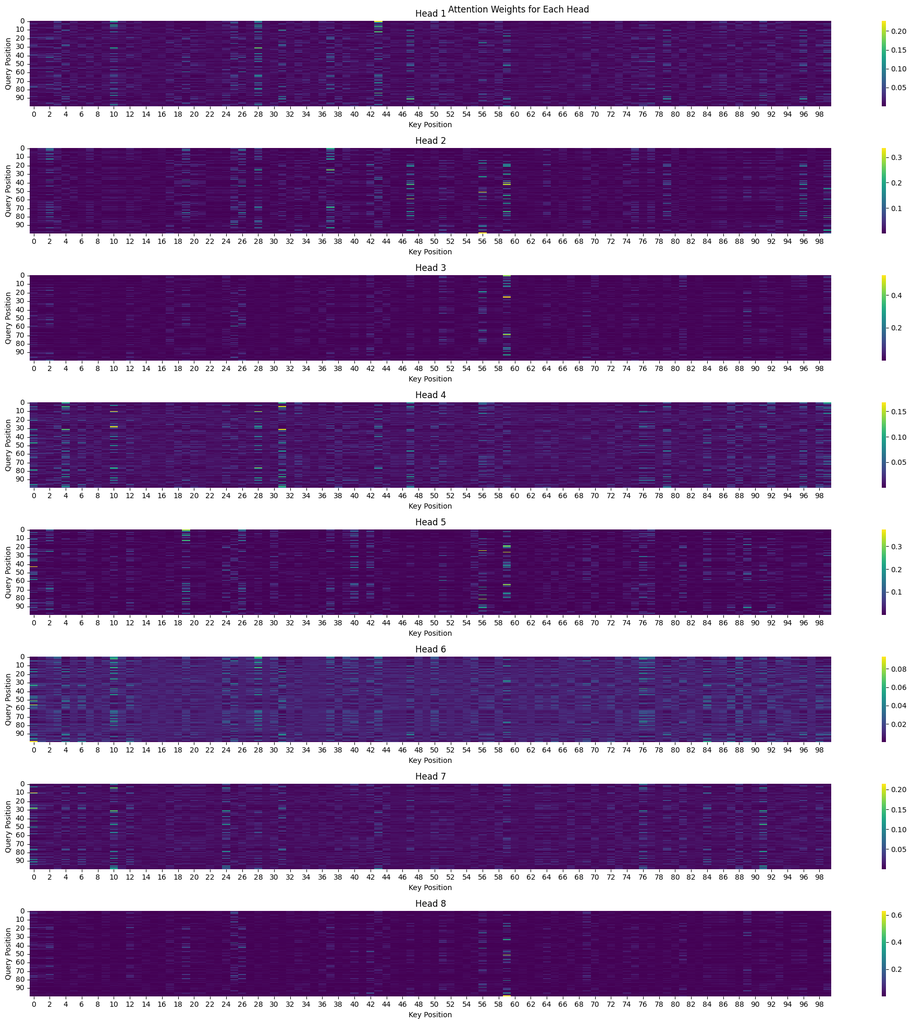

```python
num_heads = 8
output_dim = 3
d_in = 3
d_model = 64

model = Transformer(
    num_heads=num_heads,
    output_dim=output_dim,
    d_in=d_in,
    d_model=d_model)

checkpoint_path = checkpoint_dir / 'num_heads_8/best_model.pth'
print(f"Checkpoint Path : {checkpoint_path}")
# load model checkpoint
model.load_state_dict(torch.load(checkpoint_path, weights_only=True))
print("Model Loaded")

input_sequence = torch.randn(100, 3)  # Replace with actual input data of sequence length 100

visualize_attention_weights(model, input_sequence)
```